# Second R Practical: Data Frames & Factors

# The Agenda

- Talk about organizing, structuring & storing your data.
- Review some important data input/output options in R.
- Review about how data frames work in R.

## Setup

~2 minute setup

Make sure that your current RStudio project is set to your course project. Create and save your R notebook for today (I would recommend `02_lecture.Rmd`). Clear the workspace of anything left over from last time with the menu options `Session > Clear Workspace`.

Load the important packages for today’s work:

```r
library(languageVariationAndChangeData)
library(lsa2017)
library(tidyverse)
```

# Structuring Data

## Breaking Bad Spreadsheet Habits

Let’s start off by looking at a picture of a data organization approach that might look familiar, and is a *very bad* way to do things:

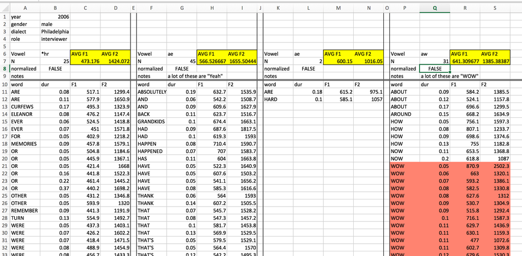

This spreadsheet has a fairly strict organizational structure, but is virtuously hopeless for doing any kind of serious statistical analysis. It’s also verging on irreparable using R. This because the data in this spreadsheet is organized to be easy to look at with your eyeballs 👀.

But looking at neatly organized data in a spreadsheet is not a statistical analysis technique. So we need to start organizing our data in a way that isn’t easy to look at, but *is* easy to graph and analyze.

## Better Habits

Everyone working with data (in R or otherwise) should read Hadley Wickham’s paper on Tidy Data: https://cran.r-project.org/web/packages/tidyr/vignettes/tidy-data.html If you are coming off of organizing your data like the picture above, there are a few guidelines not discussed in that paper, namely:

#### Follow these rules

1. The first row of the data *must* be the names of the data columns.
2. All other rows *must* be the data, and nothing else.
3. You cannot use empty rows or empty columns as visual aids to look at the data.
4. The spreadsheet must not contain any summary cells. No final row called “Average” or final column called “Total”. We can create these in R, and they make data processing more complicated if they’re included in the raw data.

### Semantics of Data Structure

In the semantics of data structure Wickham lays out, there are three important primitives:

1. Variables
2. Values
3. Observations

#### Defining the primitives

##### Variables

Variables are the collections of values of interest in data analysis. For example, let’s say you were doing a study on unnormalized vowel space size by just looking at /i:/ and /ɑ/. The variables in that study could be:

- `speaker`
- `word`
- `phoneme`
- `duration`
- `F1`
- `F2`
- `word_frequency`

##### Values

Values are, as the name implies, the possible values that each variable can have, for example:

- `speaker`: `"Oakley"`, `"Charlie"`, `"Azaria"`, `...`
- `word`: `"street"`, `"thirteen"`, `"not"`, `"got"`, `...`
- `phoneme`: `"iy"`, `"ah"`

##### Observations

An observation is the minimal unit across which all variables are collected. For example, in the vowel space study, one observation would be one instance of an uttered vowel for which you record who the speaker was, the word, the duration, F1, F2, etc.

#### Organizing data with these primitives

Once you’ve thought through what the variables, values and observations are for your study, the principle of how to organize them is simple:

1. Each variable forms a column.
2. Each observation forms a row.

For the vowel space size study, you might want to wind up with a plot that looks like this:

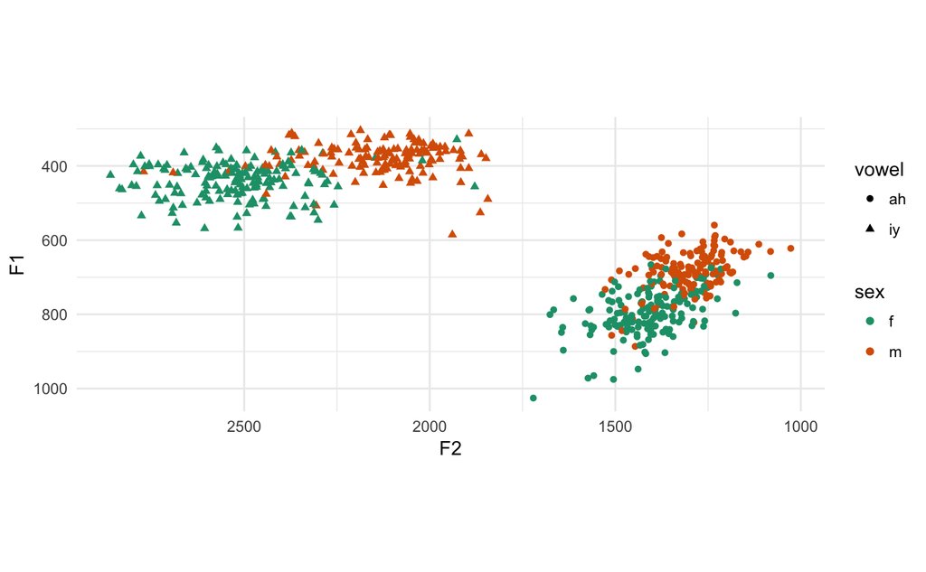

It wouldn’t be uncommon to see the data untidily organized like this:

|  | idstring | sex | age | ah_F1 | ah_F2 | iy_F1 | iy_F2 |
| --- | --- | --- | --- | --- | --- | --- | --- |
| 1 | PH00-1-1- | m | 21 | 661.3866 | 1278.020 | 441.0271 | 2034.065 |
| 2 | PH00-1-2- | f | 52 | 831.4035 | 1391.976 | 406.0202 | 2450.472 |
| 3 | PH00-1-3- | m | 18 | 631.2241 | 1267.028 | 371.8246 | 1915.340 |
| 4 | PH00-1-4- | m | 18 | 664.1353 | 1262.315 | 400.6728 | 2025.175 |
| 5 | PH00-1-5- | m | 70 | 715.8319 | 1253.072 | 381.0250 | 2089.078 |
| 6 | PH00-2-1- | f | 65 | 753.2472 | 1387.222 | 414.3717 | 2305.639 |
| 7 | PH02-1-1- | f | 93 | 762.6000 | 1517.871 | 447.8636 | 2325.591 |
| 8 | PH02-2-12- | f | 19 | 1025.6174 | 1720.891 | 494.7294 | 2728.676 |
| 9 | PH02-2-4- | f | 63 | 828.9702 | 1485.866 | 421.5275 | 2572.296 |
| 10 | PH02-2-5- | f | 59 | 798.3188 | 1322.367 | 406.6214 | 2488.733 |

[output cut: 282 more lines]

~5 Minute Activity

In small groups, figure out the following:

- What are the variables in the data frame above?
- What are the values?
- What are the observations?
- How should the table above be re-organized?

# Data Frames

So far we have discussed the following types of values in R:

- numerical
- character
- logical

And we’ve discussed the following data structures.

- vectors

Here, we’ll cover one new data structure:

- data frames

Data Frames are the data structure we’ll be using the most in R. When you begin thinking about data frames, a useful starting place is to think of them as spreadsheets, with columns and rows (but we’ll eventually abandon spreadsheet thinking). Let’s start out by creating a very simple data frame using the `data.frame()` function.

```r
  pitch <- data.frame(speaker_names = c("Charlie", "Skyler", "Sawyer", "Jamie"),
                      ages = c(18, 35, 41, 62),
                      F0 = c(114, 189, 189, 199))
  pitch
```

| speaker_names | ages | F0 |
| --- | --- | --- |
| Charlie | 18 | 114 |
| Skyler | 35 | 189 |
| Sawyer | 41 | 189 |
| Jamie | 62 | 199 |

## Finding your way around

The `pitch` data frame has four rows, and three columns. The rows are just numbered 1 through 4, and the three columns are named `speaker_names`, `ages` and `F0`. To find out how many rows and columns a data frame has, you can use the `nrow()` and `ncol()` functions.

```r
  nrow(pitch)
```

```
[1] 4
```

```r
  ncol(pitch)
```

```
[1] 3
```

Most data frames you’re going to work with have a lot more rows than that. For example, `iy_ah` is a data frame that is bundled in the `lsa2017` package.

```r
  nrow(iy_ah)
```

```
[1] 44818
```

That’s too many rows to look at just in the console. One option is to use the `head()` function, that just prints the first 6 rows.

```r
  head(iy_ah)
```

|  | idstring | age | sex | year | years_of_schooling | vowel | word | F1 | F2 | dur | plt_vclass | pre_seg | fol_seg | context | word_trans | F1_n | F2_n |
| --- | --- | --- | --- | --- | --- | --- | --- | --- | --- | --- | --- | --- | --- | --- | --- | --- | --- |
| 1 | PH00-1-1- | 21 | m | 2000 | 14 | IY | STREET | 424.2 | 2320.2 | 0.16 | iy | R | T | internal | S T R IY1 T | -1.71965040 | 2.64857706 |
| 2 | PH00-1-1- | 21 | m | 2000 | 14 | IY | THIRTEEN | 562.8 | 2191.9 | 0.05 | iy | T | N | internal | TH ER1 T IY1 N | 0.00985542 | 2.23850154 |
| 3 | PH00-1-1- | 21 | m | 2000 | 14 | AA | NOT | 634.6 | 1515.7 | 0.09 | ah | N | T | internal | N AA1 T | 0.90580432 | 0.07721497 |
| 4 | PH00-1-1- | 21 | m | 2000 | 14 | AA | GOT | 705.5 | 1458.2 | 0.11 | ah | G | T | internal | G AA1 T | 1.79052267 | -0.10656790 |
| 5 | PH00-1-1- | 21 | m | 2000 | 14 | IY | STREET | 428.3 | 2013.2 | 0.14 | iy | R | T | internal | S T R IY1 T | -1.66848897 | 1.66733634 |
| 6 | PH00-1-1- | 21 | m | 2000 | 14 | AA | NOT | 592.0 | 1458.8 | 0.08 | ah | N | T | internal | N AA1 T | 0.37422461 | -0.10465016 |

Another option is to use the `summary()` function.

```r
  summary(iy_ah)
```

```
   idstring              age            sex                 year      years_of_schooling
 Length:44818       Min.   :18.00   Length:44818       Min.   :1973   Length:44818
 Class :character   1st Qu.:30.00   Class :character   1st Qu.:1980   Class :character
 Mode  :character   Median :45.00   Mode  :character   Median :1985   Mode  :character
                    Mean   :46.69                      Mean   :1989
                    3rd Qu.:65.00                      3rd Qu.:2002
                    Max.   :93.00                      Max.   :2010
    vowel               word                 F1               F2              dur
 Length:44818       Length:44818       Min.   : 186.6   Min.   : 598.6   Min.   :0.0500
 Class :character   Class :character   1st Qu.: 398.3   1st Qu.:1355.1   1st Qu.:0.0800
 Mode  :character   Mode  :character   Median : 528.6   Median :1879.5   Median :0.1100
                                       Mean   : 570.6   Mean   :1889.1   Mean   :0.1214
                                       3rd Qu.: 732.5   3rd Qu.:2386.7   3rd Qu.:0.1500
                                       Max.   :1428.9   Max.   :3690.4   Max.   :0.8700
  plt_vclass          pre_seg            fol_seg            context           word_trans
 Length:44818       Length:44818       Length:44818       Length:44818       Length:44818
 Class :character   Class :character   Class :character   Class :character   Class :character
 Mode  :character   Mode  :character   Mode  :character   Mode  :character   Mode  :character



      F1_n              F2_n
 Min.   :-3.0055   Min.   :-2.4533
 1st Qu.:-1.4855   1st Qu.:-0.7021
 Median :-0.7261   Median : 0.8525
 Mean   :-0.2476   Mean   : 0.5639
 3rd Qu.: 1.0521   3rd Qu.: 1.7315
 Max.   : 4.3707   Max.   : 4.8674
```

`summary()` is a function that works on almost every kind of object.

## Indexing Data Frames

Since data frames are 2 dimensional (rows are one dimension, columns are another), the way you index them is a little bit more complicated than with vectors. It still uses square brackets, though, but these square brackets have two positions:

df[row number, column number]

If you specify a specific row number, but leave the column number blank, you’ll get back that row and all columns.

```r
  pitch[1,]
```

|  | speaker_names | ages | F0 |
| --- | --- | --- | --- |
| 1 | Charlie | 18 | 114 |

Alternatively, if you specify just the column number, but leave the rows blank, you’ll get back all of the values for that column.

```r
  pitch[,2]
```

```
[1] 18 35 41 62
```

When you specify both, you get back the value in the specified row and column

```r
  pitch[1,2]
```

```
[1] 18
```

However, there is a special indexing operator for data frames that take advantage of their named columns: `$`.

df$column_name

```r
  pitch$speaker_names
```

```
[1] Charlie Skyler  Sawyer  Jamie
Levels: Charlie Jamie Sawyer Skyler
```

After accessing the column of a data frame, you can index it just like it’s a vector.

```r
  pitch$speaker_names[1]
```

```
[1] Charlie
Levels: Charlie Jamie Sawyer Skyler
```

If you really want to, you can do logical indexing of data frames like so:

```r
  pitch[pitch$speaker_names == "Charlie", ]
```

|  | speaker_names | ages | F0 |
| --- | --- | --- | --- |
| 1 | Charlie | 18 | 114 |

But there’s also a function called `filter()` that you can use to do the same thing. `filter()` takes a data frame as its first argument, and then a logical statement referring to one or more of the data frame’s columns.

```r
  filter(pitch, speaker_names == "Charlie")
```

| speaker_names | ages | F0 |
| --- | --- | --- |
| Charlie | 18 | 114 |

```r
  filter(pitch, ages > 18, F0 > 190)
```

| speaker_names | ages | F0 |
| --- | --- | --- |
| Jamie | 62 | 199 |

~5 Minute Activity

First, review the documentation of the `iy_ah` data set with `?iy_ah`. Using `filter()` and `nrow()`, find out what percent of /i:/ tokens have a duration less than 90ms (0.09s).